# Datenstruktur Dashboard Uploads

Zi Data Science Lab | Lars Kroll

17 6 2021

## Uploads in das Zi Dashboard System

Uploads erfolgen als csv Dateien mit dem Trennzeichen “,”. Die Dateien sollten vollständig sein und im Hinblick auf die regionale Zuordung gruppiert werden. Beim Upload der Datendatei muss angegeben werden, um welchen Variablentyp es sich handelt.

*Datei Upload Formular*

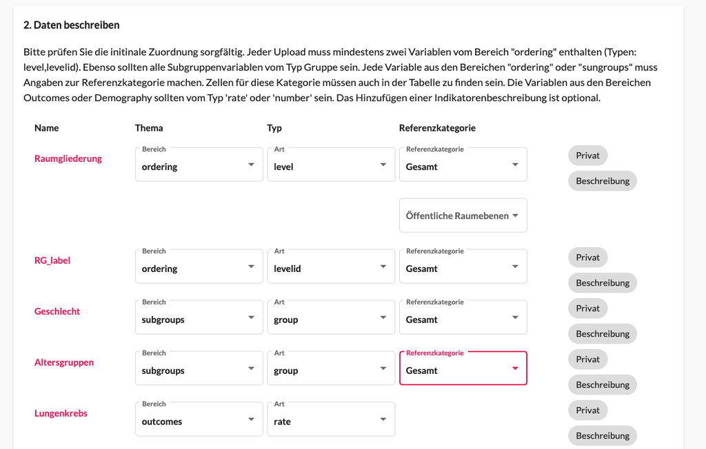

*Beispiel eines Uploads mit der Ebenen-Variable Raumgliederung und der Einheiten Variable RG_Label sowie zwei Gruppen Variablen*

## Beispieldaten

```r
library(dplyr)
library(kableExtra)
Ebenen <- c("Gesamt","Ebene 1", "Ebene 2")
Einheiten <- c("Gesamt","Einheit 1","Einheit 2","Einheit 3")
Subgruppe1 <- c("Gesamt","Gruppe A","Gruppe B")
Subgruppe2 <-  c("Gesamt","Gruppe C","Gruppe D")
```

# Beispiel 1: *Subgruppen* werden nur für Ebene *Gesamt* berichtet

Sollen nicht für alle räumlichen Ebenen Werte für die Subgruppen ausgewiesen werden, müssen allerdings zumindest Gesamtwerte für die Subgruppen ausgewiesen werden. Es darf keine fehlenden Werte bei den Subgruppen geben.

| Ebene | Einheit | Gruppe1 | Gruppe2 | Indikator_1 |
| --- | --- | --- | --- | --- |
| Gesamt | Gesamt | Gesamt | Gesamt | 0.2532041 |
| Gesamt | Gesamt | Gesamt | Gruppe C | 0.8786773 |
| Gesamt | Gesamt | Gesamt | Gruppe D | 0.6088858 |
| Gesamt | Gesamt | Gruppe A | Gesamt | 0.5185003 |
| Gesamt | Gesamt | Gruppe A | Gruppe C | 0.8583067 |
| Gesamt | Gesamt | Gruppe A | Gruppe D | 0.9681490 |
| Gesamt | Gesamt | Gruppe B | Gesamt | 0.5095650 |
| Gesamt | Gesamt | Gruppe B | Gruppe C | 0.3207136 |
| Gesamt | Gesamt | Gruppe B | Gruppe D | 0.8245608 |
| Ebene 1 | Einheit 1 | Gesamt | Gesamt | 0.5444806 |
| Ebene 1 | Einheit 2 | Gesamt | Gesamt | 0.5985384 |
| Ebene 1 | Einheit 3 | Gesamt | Gesamt | 0.3646706 |
| Ebene 2 | Einheit 1 | Gesamt | Gesamt | 0.0796576 |
| Ebene 2 | Einheit 2 | Gesamt | Gesamt | 0.7820381 |
| Ebene 2 | Einheit 3 | Gesamt | Gesamt | 0.9352337 |

# Beispiel 2: **Alle** Subgruppen für **alle** Ebenen

| Ebene | Einheit | Gruppe1 | Gruppe2 | Indikator_1 |
| --- | --- | --- | --- | --- |
| Gesamt | Gesamt | Gesamt | Gesamt | 0.4732135 |
| Gesamt | Gesamt | Gesamt | Gruppe C | 0.5086133 |
| Gesamt | Gesamt | Gesamt | Gruppe D | 0.6938539 |
| Gesamt | Gesamt | Gruppe A | Gesamt | 0.9742786 |
| Gesamt | Gesamt | Gruppe A | Gruppe C | 0.6432544 |
| Gesamt | Gesamt | Gruppe A | Gruppe D | 0.6753295 |
| Gesamt | Gesamt | Gruppe B | Gesamt | 0.7973190 |
| Gesamt | Gesamt | Gruppe B | Gruppe C | 0.3771687 |
| Gesamt | Gesamt | Gruppe B | Gruppe D | 0.6150707 |
| Ebene 1 | Gesamt | Gesamt | Gesamt | 0.4374026 |
| Ebene 1 | Gesamt | Gesamt | Gruppe C | 0.9953104 |
| Ebene 1 | Gesamt | Gesamt | Gruppe D | 0.1581490 |
| Ebene 1 | Gesamt | Gruppe A | Gesamt | 0.1494616 |
| Ebene 1 | Gesamt | Gruppe A | Gruppe C | 0.5970271 |
| Ebene 1 | Gesamt | Gruppe A | Gruppe D | 0.8942365 |
| Ebene 1 | Gesamt | Gruppe B | Gesamt | 0.8693498 |
| Ebene 1 | Gesamt | Gruppe B | Gruppe C | 0.3811959 |
| Ebene 1 | Gesamt | Gruppe B | Gruppe D | 0.5649605 |
| Ebene 1 | Einheit 1 | Gesamt | Gesamt | 0.0087750 |
| Ebene 1 | Einheit 1 | Gesamt | Gruppe C | 0.5383929 |
| Ebene 1 | Einheit 1 | Gesamt | Gruppe D | 0.7662061 |
| Ebene 1 | Einheit 1 | Gruppe A | Gesamt | 0.7993730 |
| Ebene 1 | Einheit 1 | Gruppe A | Gruppe C | 0.0064448 |
| Ebene 1 | Einheit 1 | Gruppe A | Gruppe D | 0.4976533 |
| Ebene 1 | Einheit 1 | Gruppe B | Gesamt | 0.1749724 |
| Ebene 1 | Einheit 1 | Gruppe B | Gruppe C | 0.9348204 |
| Ebene 1 | Einheit 1 | Gruppe B | Gruppe D | 0.1567484 |
| Ebene 1 | Einheit 2 | Gesamt | Gesamt | 0.0677095 |
| Ebene 1 | Einheit 2 | Gesamt | Gruppe C | 0.2441777 |
| Ebene 1 | Einheit 2 | Gesamt | Gruppe D | 0.9250103 |

[output cut: 51 more lines]

Zwischen beiden Beispielen sind auch Mischformen denkbar. Ebenso möglich ist es, dass für eine Ebenen/Subgruppenkombination keine Werte für einen Indikator berichtet werden.

# GEODATEN

Geodaten müssen als GEOJSON hochgeladen werden. Sie müssen unter Properties eine ID Variable enthalten, deren Werte auch in der Datendatei zu finden sind. Es ist aber möglich, dass die Variablen in der Datendatei und der GEOJSON Datei anders bezeichnet sind.

Als Projektion für die Koordinaten in der GEOJSON Datei muss das System (EPSG:3857)[https://wiki.openstreetmap.org/wiki/EPSG:3857] verwendet werden. Die Angabe eines CRS in der GEOJSON Datei ist nicht nötig.